# First_Markdown

Madie Tong

2024-01-20

# Learning Goals and Interests

## Graphic

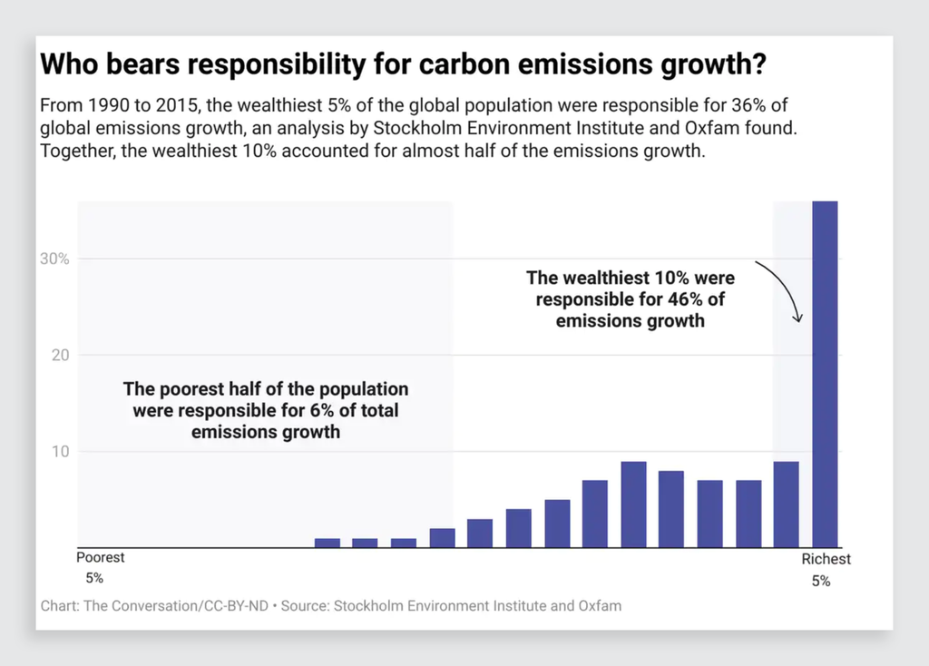

https://www.fastcompany.com/90693644/these-6-charts-explain-the-concept-of-climate-justice

## Links to Sustainability-related data sets

1. https://catalog.data.gov/dataset/human-well-being-index-hwbi-for-u-s-counties-2000-20101
2. https://www.earthdata.nasa.gov/learn/environmental-justice-data-catalog

## Learning Objectives from Engineering for One Planet Framework

- “Apply relevant concepts from required disciplines to the study of real-world problems and their solutions with empathic and ethical consideration for communities/societies, environmental justice, and cultural awareness.”
- “Examine data about environmental issues (e.g., climate change, energy and water use, scarcity and pollution, air quality, waste management, toxicity, etc.) including consideration for past/current/ future and local/regional/global impacts”
- ” Describe how engineering activities directly and indirectly cause positive and negative social/ cultural impacts throughout the design life-cycle, both to workers producing the products (i.e., labor practices, livelihood, health, etc.) and to communities, society, and non-human life (i.e., resources acquisition, waste production and management, traditional/cultural methodologies, etc.).”

## Sustainability-related Questions

- I’m curious what measures are being taken now on a government/higher level that is aimed at funneling more resources into impoverished communities who are unequitably affected by exposure to hazardous materials, polluted air, etc?
- What are ways that data can be used effectively in pushing for change in environmental injustice?
- What are roles that data scientists take that are more climate-minded versus what other data scientists take? How may skills differ?

# Exercise 3.2 Data

```r
# load package
library(lterdatasampler)

# load data
data("ntl_icecover")

# assign data to new variable
ntl <- ntl_icecover
```

2. There are 334 units of observation, noting the year and duration of ice sticking in various lakes

```r
# c) First 12 rows of data
head(ntl,12)
```

```
##          lakeid     ice_on    ice_off ice_duration year
## 1  Lake Mendota       <NA> 1853-04-05           NA 1852
## 2  Lake Mendota 1853-12-27       <NA>           NA 1853
## 3  Lake Mendota 1855-12-18 1856-04-14          118 1855
## 4  Lake Mendota 1856-12-06 1857-05-06          151 1856
## 5  Lake Mendota 1857-11-25 1858-03-26          121 1857
## 6  Lake Mendota 1858-12-08 1859-03-14           96 1858
## 7  Lake Mendota 1859-12-07 1860-03-26          110 1859
## 8  Lake Mendota 1860-12-14 1861-04-10          117 1860
## 9  Lake Mendota 1861-12-02 1862-04-13          132 1861
## 10 Lake Mendota 1862-12-26 1863-04-09          104 1862
## 11 Lake Mendota 1863-12-18 1864-04-21          125 1863
## 12 Lake Mendota 1864-12-08 1865-04-05          118 1864
```

```r
# d) List of all variable names
names(ntl)
```

```
## [1] "lakeid"       "ice_on"       "ice_off"      "ice_duration" "year"
```

```r
# e) Class of lakeid and ice_off variables
class(ntl$lakeid)
```

```
## [1] "factor"
```

```r
class(ntl$ice_off)
```

```
## [1] "Date"
```

```r
# f) All unique entries of lakeid variable
levels(ntl$lakeid)
```

```
## [1] "Lake Mendota" "Lake Monona"  "Lake Wingra"
```